# POPL 2015 Survey

Jan Vitek, for the SIGPLAN Executive Committee

March 29, 2015

This poll was conducted in January 2015. Invitations were sent to attendees of the POPL’15 conference in Mumbai. There were **163** responses. The last three of the questions were related to open access and publishing.

When asked whether open access is important to them 81% agreed. The definition of open access for that question was: “*Anyone should be able to download papers from the ACM digital library with no fee or membership requirement.*”

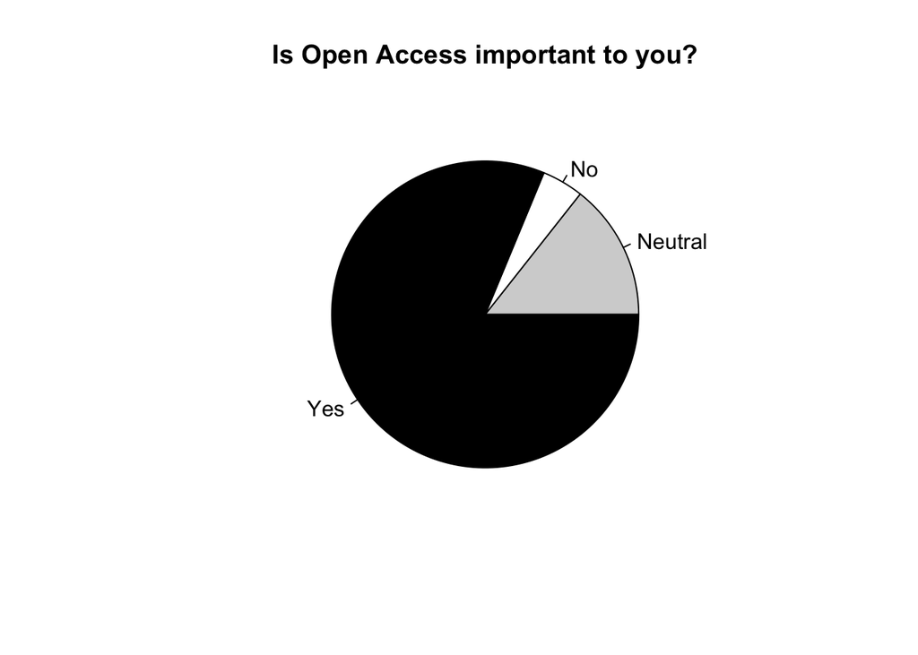

When asked what would be acceptable author processing charges, 83% chose $100 or less.

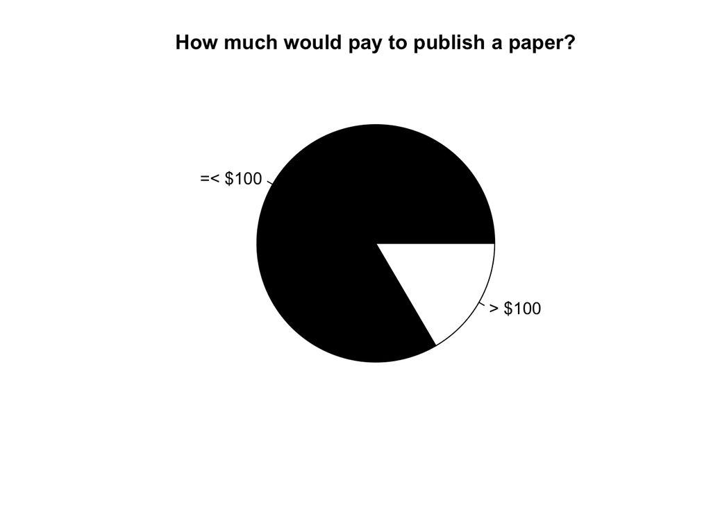

The last question ask if the respondents would support publishing the proceedings of POPL as a special issue of TOPLAS? The question explained that: “*A similar proposal is being considered for PLDI. This would not prevent long form papers from being submitted to TOPLAS, but would mean that POPL papers could be listed as journal publications.*” There were 79% of the respondents in favor.

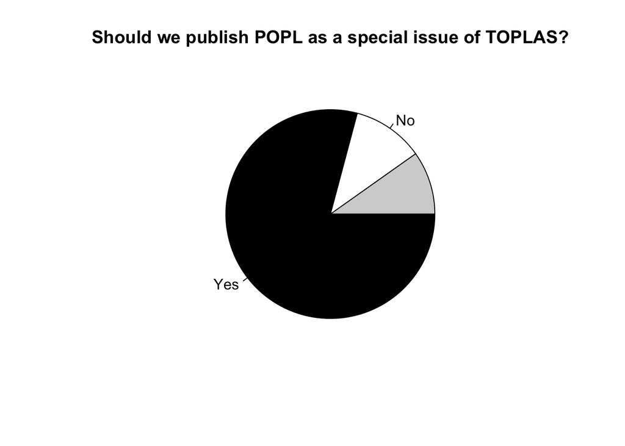

### Repeatability

A PDF file with questions asked in this poll is [here](http://janvitek.org/who/popl/survey.pdf).

A CSV file with answers is [here](http://janvitek.org/who/popl/data.csv).

A PDF file with the Google Form overview of the responses is [here](http://janvitek.org/who/popl/results.pdf).

The R Markdown code for this document is [here](http://janvitek.org/who/popl/index.Rmd).